# Analysis of Covariance

## Warm Up

**Activity #7 Part I**

- Revisit the RailTrail data set from Activity 4.
- Consider two models: a) SLR model to predict ridership by temperature, b) same approach but with added quadratic term.
- Discuss the relative merits of the two models.

## Disclaimer

For the rest of the week, we won't talk at all about assessing model validity (looking at residual plots). that step is **absolutely vital**, but we're putting it on hold till next week.

## Example: Textbooks

[figure not shown]

Consider a sample of 15 textbooks. How well can we predict weight by volume?

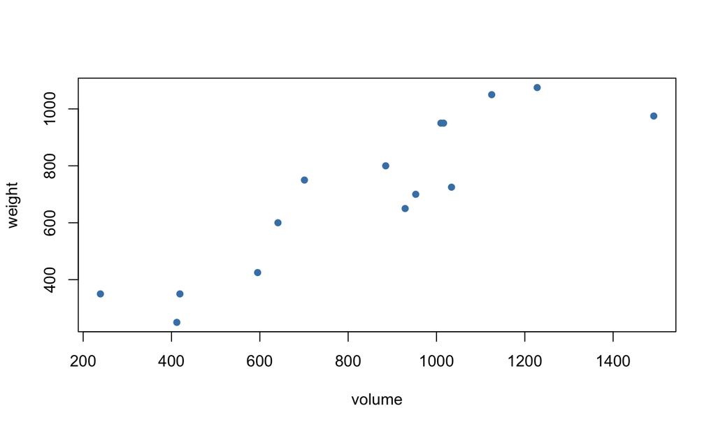

Consider a sample of 15 textbooks. How well can we predict weight by volume?

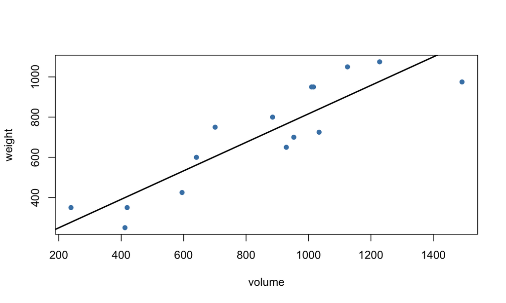

```r
summary(m1)
```

```
##
## Call:
## lm(formula = weight ~ volume, data = allbacks)
##
## Residuals:
##    Min     1Q Median     3Q    Max
## -190.0 -109.9   38.1  109.7  145.6
##
## Coefficients:
##             Estimate Std. Error t value Pr(>|t|)
## (Intercept) 107.6793    88.3776    1.22     0.24
## volume        0.7086     0.0975    7.27  6.3e-06 ***
## ---
## Signif. codes:  0 '***' 0.001 '**' 0.01 '*' 0.05 '.' 0.1 ' ' 1
##
## Residual standard error: 124 on 13 degrees of freedom
## Multiple R-squared:  0.803,  Adjusted R-squared:  0.787
## F-statistic: 52.9 on 1 and 13 DF,  p-value: 6.26e-06
```

## Adding a categorical predictor

```r
allbacks[c(1, 2, 9, 10), ]
```

```
##    volume area weight cover
## 1     885  382    800    hb
## 2    1016  468    950    hb
## 9     953    0    700    pb
## 10    929    0    650    pb
```

We should be able to better predict the weight if we use both the volume *and* knowledge of the type of cover.

## Adding a categorical predictor

```r
class(allbacks$cover)
```

```
## [1] "factor"
```

```r
levels(allbacks$cover)
```

```
## [1] "hb" "pb"
```

```r
m2 <- lm(weight ~ volume + cover, data = allbacks)
```

- Categorial variables in R are of the class `factor`. Check with `class()`, coerce with `as.factor()`.
- Modeling a continuous variable used a continuous variable and a categorical variable is known as Analysis of Covariance.

## How R thinks of his model

```r
summary(m2)$coef
```

```
##             Estimate Std. Error t value  Pr(>|t|)
## (Intercept)  197.963   59.19274   3.344 5.841e-03
## volume         0.718    0.06153  11.669 6.598e-08
## coverpb     -184.047   40.49420  -4.545 6.719e-04
```

## Simple linear legression

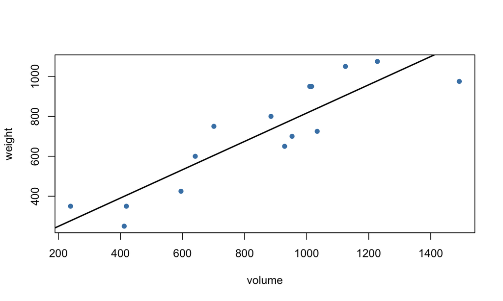

\[ \widehat{weight} = 107.70 + 0.71 volume \]

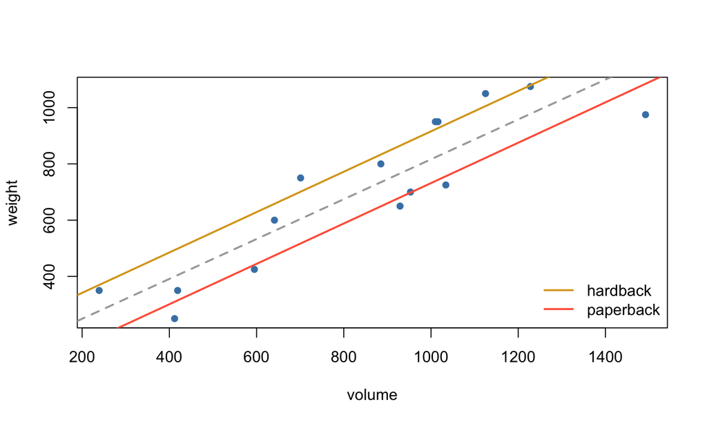

\[ \widehat{weight}_{hb} = 197.96 + 0.72 volume \\ \widehat{weight}_{pb} = 13.91 + 0.72 volume \]

## Comparing explanatory power

```r
summary(m1)$r.squared
```

```
## [1] 0.8026
```

```r
summary(m2)$r.squared
```

```
## [1] 0.9275
```

```r
summary(m1)$adj.r.squared
```

```
## [1] 0.7875
```

```r
summary(m2)$adj.r.squared
```

```
## [1] 0.9154
```

## Adding more complexity?

We've established that this data is best modeled with two intercepts, but should the two lines have their own slopes as well?

\[ \widehat{weight} = \beta_0 + \beta_1 volume + \beta_2 coverpb + \beta_3 volume * coverpb \]

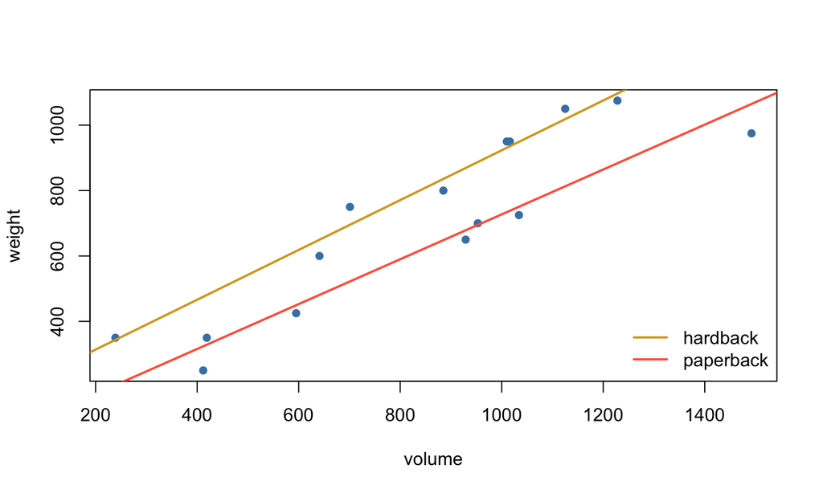

```r
m3 <- lm(weight ~ volume * cover, data = allbacks)
summary(m3)
```

```
##
## Call:
## lm(formula = weight ~ volume * cover, data = allbacks)
##
## Residuals:
##    Min     1Q Median     3Q    Max
##  -89.7  -32.1  -21.8   17.9  215.9
##
## Coefficients:
##                 Estimate Std. Error t value Pr(>|t|)
## (Intercept)     161.5865    86.5192    1.87    0.089 .
## volume            0.7616     0.0972    7.84  7.9e-06 ***
## coverpb        -120.2141   115.6590   -1.04    0.321
## volume:coverpb   -0.0757     0.1280   -0.59    0.566
## ---
## Signif. codes:  0 '***' 0.001 '**' 0.01 '*' 0.05 '.' 0.1 ' ' 1
##
## Residual standard error: 80.4 on 11 degrees of freedom
## Multiple R-squared:  0.93,   Adjusted R-squared:  0.911
## F-statistic: 48.5 on 3 and 11 DF,  p-value: 1.24e-06
```

## Which is better?

The interaction terms is insignificant, suggesting that the two classes of books might not follow different trends between their volume and weights.

Note that it also made the intercept term insignificant as well.

## Activity #7 Part II

- Revisit the twins data set from the quiz.
- Is there evidence that the relationship between IQs differs between the social status groups (intercepts or slopes)?